# Personal Activity Monitoring Data Analysis

Noel Cosgrave

This analysis is of data generated by a personal activity monitoring device which monitors activity at 5 minute intervals. The variables included in this dataset are:

- **steps**: The number of steps taking during a given 5-minute interval
- **date**: The date of the measurement in YYYY-MM-DD format
- **interval**: A code identifying the 5-minute interval during which the measurement was taken.

Missing values are coded as NA.

## Loading and preprocessing the data

We need to first unzip the compressed activity data file, downloading it if necessary. We then load the unzipped data into a variable named **activity_data** using the *read.csv* function.

```r
if(!file.exists("activity.zip")) {
   download.file("https://d396qusza40orc.cloudfront.net/repdata/data/activity.zip", "activity.zip")
}
unzip("activity.zip")
activity_data <- read.csv("activity.csv", header = TRUE, colClasses = c("integer","Date","integer"))
```

## What is the mean total number of steps taken per day?

We first need to load the **ggplot2** package that we will use to plot the data.

```r
library("ggplot2")
```

We next use the aggregate function to calculate the sum of the **steps** column for each unique value in the **date** column as daily totals. We can then display these aggregated values using a histogram, using the **ggplot2** package.

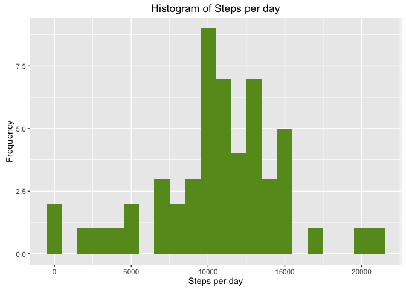

```r
activity_by_date <- aggregate(steps~date,data = activity_data, FUN=sum, na.rm=TRUE)
ggplot(activity_by_date, aes(x = steps)) +
  geom_histogram(fill = "#669922", binwidth = 1000) +
  labs(title = "Histogram of Steps per day", x = "Steps per day", y = "Frequency")
```

Finally, we can then use standard functions to display the median and mean of the daily total number of steps.

```r
median(activity_by_date$steps)
```

```
## [1] 10765
```

```r
mean(activity_by_date$steps)
```

```
## [1] 10766.19
```

## What is the average daily activity pattern?

We can gain a general impression of the daily activity pattern by plotting the mean activity by interval using a line plot. This is done using the *ggplot2* library loaded earlier.

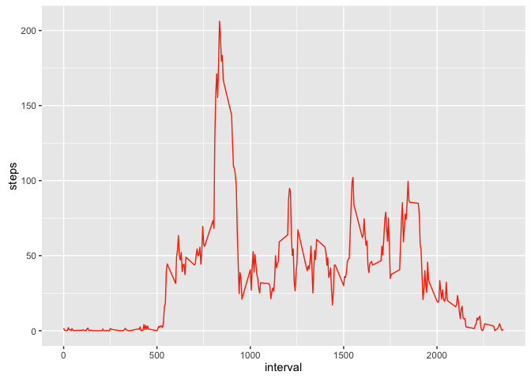

```r
activity_mean_by_interval <- aggregate(steps~interval,data = activity_data, FUN=mean, na.rm=TRUE)
ggplot(activity_mean_by_interval, aes(x=interval, y=steps)) +
  geom_line(color = "#FF3300")
```

Although the time series plot above shows that the most active interval is somewhere between 800 and 900, we will need to use the *which.max* function to determine precisely which interval contains the maximum number of steps.

```r
activity_mean_by_interval[which.max(activity_mean_by_interval$steps),]
```

```
##     interval    steps
## 104      835 206.1698
```

This shows that most activity takes place in interval 835.

## Imputing missing values

The data contain a number of rows with NA values in the *steps* column. To determine the number of rows containing NAs, we can sum the number of TRUE values (1s) returned by the **is.na** function.

```r
sum(is.na(activity_data$steps))
```

```
## [1] 2304
```

Having established the number of rows containing NA values, we can then impute the missing values.The first task is to return a vector containing a logical value indicating whether a row contains NAs or not. We then use the tagged apply function **tapply** to calculate the mean value for each interval and store it into an array (named *mean_by_interval*) indexed by the interval value. Finally, we use the data in *mean_by_interval* to set the imputed values in place of the NAs.

```r
activity_with_imputed <- activity_data
na_steps <- is.na(activity_with_imputed$steps)
mean_by_interval <- tapply(activity_with_imputed$steps, activity_with_imputed$interval, mean, simplify=TRUE, na.rm=TRUE)
activity_with_imputed$steps[na_steps] <- mean_by_interval[as.character(activity_with_imputed$interval[na_steps])]
```

We can then check that there are no NA values remaining in the dataset by summing the result of the **is.na** function run on all the data.

```r
sum(is.na(activity_with_imputed))
```

```
## [1] 0
```

[figure not shown]

```r
activity_by_date_imputed <- aggregate(steps~date,data = activity_data, FUN=sum, na.rm=TRUE)
ggplot(activity_by_date_imputed, aes(x = steps)) +
  geom_histogram(fill = "#759021", binwidth = 1000) +
  labs(title = "Histogram of Steps per day with imputed values", x = "Steps per day", y = "Frequency")
```

## Are there differences in activity patterns between weekdays and weekends?

We first have to create a new computed column containing a logical value indicating whether the data in the row pertain to a weekend or weekday. This is done by testing if the value returned by the **weekdays** function is found in the list of weekend days. We then aggregate and plot the data for the weekend and weekdays separately, but as part of a faceted plot arrangement.

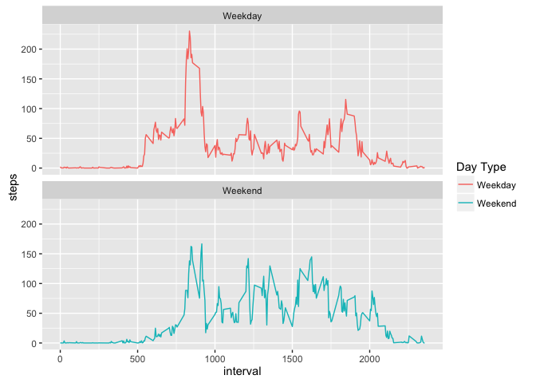

```r
activity_with_imputed$daytype <- weekdays(activity_with_imputed$date) %in% c("Saturday","Sunday")
activity_with_imputed$daytype <- c("Weekday","Weekend")[activity_with_imputed$daytype+1]
activity_mean_by_interval_daytype <- aggregate(steps~interval+daytype,data = activity_with_imputed, FUN=mean, na.rm=TRUE)

ggplot(activity_mean_by_interval_daytype, aes(x=interval, y=steps, color=daytype)) +
  geom_line()+
  labs(colour = "Day Type")+
  facet_wrap(~daytype,ncol=1,nrow=2)
```

On examining the two time series, it is clear that the activity patterns are different on the weekends than on weekdays.

Examining the mean and standard deviation for weekdays

```r
mean(activity_with_imputed[activity_with_imputed$daytype=="Weekday",]$steps)
```

```
## [1] 35.61058
```

```r
sd(activity_with_imputed[activity_with_imputed$daytype=="Weekday",]$steps)
```

```
## [1] 104.2188
```

and the mean and standard deviation for weekends

```r
mean(activity_with_imputed[activity_with_imputed$daytype=="Weekend",]$steps)
```

```
## [1] 42.3664
```

```r
sd(activity_with_imputed[activity_with_imputed$daytype=="Weekend",]$step)
```

```
## [1] 108.231
```